# Part of Speech Tagging

Erin M. Buchanan

2020-11-29

# Recap

- We have established that text is very messy and requires a good bit of work to clean it up
- No one set of steps, but you have learned a list of possible things to do when working with text
- Let’s go on now to how we can begin to process and label text

# Syntax

- Syntax is a set of rules that we use to put words together to create “well-formed” sentences
- Words –> phrases –> clauses –> sentences –> paragraphs –> discourse
- Remember a *constituent* is a member of the current set you are examining:
  - Words are members of phrases and sentences
  - Phrases are members of sentences
  - Etc.

# Syntax

- One of the most important rules is word order - if we scramble the words in a sentence, the meaning is often lost
- However, it is not the only rule:
  - Colorless green ideas sleep furiously.
- Yet word order gives us the most clues on how to process or *parse* a sentence

# Words

- Smallest unit of independent language with meaning
  - Morphemes are the smallest unit of meaning, however, they are not always independent
  - Cat versus cat-s
- We will spend this section thinking about how to classify words into their parts of speech (POS)

# Common POS

- Noun: words that depict objects or entities, but also can be abstract
- Verb: words that depict some action, states, occurrences
- Adjectives: words that describe or qualify nouns
- Adverbs: words that describe or qualify verbs
- …and more! Learn more at partofspeech.org

# A quick example

```python
##python chunk
import spacy
import pandas as pd

#this is very common naming to get spacy langauge models started
nlp = spacy.load('en_core_web_sm')

sentence = "We cannot, nor would we, fire Professor Person for his posts as a private citizen, as vile and stupid as they are, because the First Amendment of the United States Constitution forbids us to do so, she wrote in a letter posted to the university website."
```

# A quick example

```python
##python chunk
spacy_pos_tagged = [(word, word.tag_, word.pos_) for word in nlp(sentence)]
pd.DataFrame(spacy_pos_tagged).T
```

```
##      0     1     2      3      4   ...   48   49          50       51     52
## 0    We   can   not      ,    nor  ...   to  the  university  website      .
## 1   PRP    MD    RB      ,     CC  ...   IN   DT          NN       NN      .
## 2  PRON  VERB  PART  PUNCT  CCONJ  ...  ADP  DET        NOUN     NOUN  PUNCT
##
## [3 rows x 53 columns]
```

# Phrases

- Phrases include one or more words that break into the following categories
  - Noun phrase: noun is the head word, usually depicting the actor or actee in a sentence
  - Verb phrase: the verb acts as the head word, usually depicting the action in the sentence
- Within these two main phrase types, we can also define:
  - Prepositional phrase: used when there is a preposition that modifies a previous phrase (going *up* the stairs)
  - Adjective or adverb phrases: used when there is a modifier that refers to an earlier verb or noun phrase (the cat is *quick*)

# Phrases

- We will cover these more in our entity recognition and dependency parsing sections
- First, we have to figure out how to tag parts of speech to be able to do phrase tagging
- Understanding words and phrases also helps us understand grammar - a set of rules on how to construct sentences

# Grammars

- Dependency grammar - generally focuses on the words in a sentence and their dependency on each other
  - Often verb focused, as the verb determines the required dependencies
  - Uses part of speech and word order to help determine those dependencies
- Constituency grammar - sometimes called phrase structure grammars, which build sentences hierarchically
  - More commonly used because the rules are more structured - a sentence breaks into a noun phrase and verb phrase, noun phrases often contain determiners, adjectives, and nouns, etc.

# A note on POS Taggers

- There are many parts of speech:
  - A noun can be labeled Noun, plural noun, proper noun, etc.
  - A verb can be labeled with tense options
  - A conjunction can be coordinating, subordinating or just a conjunction
  - etc.

# A note on POS Taggers

- What does that mean for POS taggers?
  - You have to define the level of specificity you want to work with
  - Depends on the corpus used for the task
  - Depends on the training for the tagger
  - The set of possible tags used are called *tag sets*

# How can we decide how to tag words?

- Dictionary look-up: simply look up the word in a predefined dictionary (WordNet, PennTreeBank)
  - Look-up is fast, but very error prone
  - Why? Polysemy!
- Morphological clues: much like regular expressions, looks for specific morphemes
  - Things like *ing* indicate a verb as a present participle or gerund
  - Things like *ly* indicate an adverb
  - Works pretty well, but still prone to errors

# How can we decide how to tag words?

- Syntactic clues: uses the context or the words around it to help determine part of speech
  - Can be very slow because you have to parse in larger units
  - More accurate but requires very large training corpus
- Semantic clues: uses the meaning of the word to help determine class
  - Depending on sentence structure, this may work great, but polysemy is still a problem.

# How to POS tag

- How exactly do these automatic taggers work?
- We will discuss a few packages and options on how to tag in *R*
- Then we will discuss classic tagging using *nltk* as a contrast to state of the art tagging with *spaCy* in Python

# How do taggers work?

- It’s technically considered a machine learning problem
- Steps to any classification problem:
  - Data preparation: clean up the data (last week’s lecture)!
  - Features: Useful attributes from the data (words, letters, sentences, etc.)
  - Feature extraction: collect the useful features in the data to help classify categories

# How do taggers work?

- Steps to any classification problem:
  - Training data: data that includes the raw inputs (text) and the correct classification (POS tags) in order to check our work
  - Testing/validation data: data that includes the raw inputs and correct classifications that we then use to verify our classifiers
  - Model: the data is combined with a machine learning algorithm to build a classifier/tagger/chunker/parser/etc.
  - Accuracy: a measure of how well your model performs

# POS Tagging with automatic classification

- Any pre-trained tagger has been built using:
  - A tagged corpus for training and testing data
    - Examples include the Brown Corpus, British National Corpus, and a few others
  - A feature set that is appropriate for the task and algorithm
    - Bag of words method, n-grams, etc.
  - An algorithm: default tagging, regular expressions, hidden markov, naive bayes, etc.

# Automatic POS Tagging in *R*

- There appear to be a variety of options for tagging in *R*
- Going to demonstrate a few of them, using `RDRPOSTagger`, `openNLP`, `pos_tags` from `qdap`
- Many of the setups involve installing external programs like TreeTagger

```r
##r chunk
devtools::install_github("trinker/termco")
devtools::install_github("trinker/coreNLPsetup")
devtools::install_github("trinker/tagger")
install.packages("qdap")
devtools::install_github("bnosac/RDRPOSTagger", INSTALL_opts="--no-multiarch")
```

# Tagger Package

- You will have to make sure you have installed `rJava` and have a JDK working
- For these functions, you simply put in your text, you do not have to tokenize first
- Uses `openNLP` to do the tagging

```r
##r chunk
sentence = py$sentence

library(tagger)
tag_pos(sentence)
```

```
## [1] "We/PRP cannot/MD ,/, nor/CC would/MD we/PRP ,/, fire/NN Professor/NNP Person/NNP for/IN his/PRP$ posts/NNS as/IN a/DT private/JJ citizen/NN ,/, as/IN vile/JJ and/CC stupid/JJ as/IN they/PRP are/VBP ,/, because/IN the/DT First/NNP Amendment/NNP of/IN the/DT United/NNP States/NNP Constitution/…
```

# Tagger Package

- This package also comes with some nice plotting functions

```r
##r chunk
library(dplyr)
```

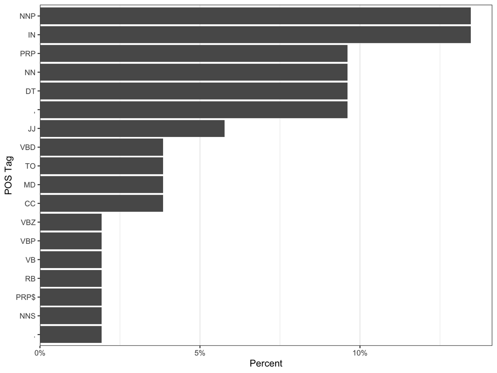

```r
tag_pos(sentence) %>% plot()
```

# Tagger Package

- What are these tags? What is the tag set?

```r
##r chunk
penn_tags()
```

```
##    Tag  Description
## 1  $    dollar
## 2  ``   opening quotation mark
## 3  ''   closing quotation mark
## 4  (    opening parenthesis
## 5  )    closing parenthesis
## 6  ,    comma
## 7  -    dash
## 8  .    sentence terminator
## 9  :    colon or ellipsis
## 10 CC   conjunction, coordinating
## 11 CD   numeral, cardinal
## 12 DT   determiner
## 13 EX   existential there
## 14 FW   foreign word
```

[output cut: 31 more lines]

# Tagger Package

- You can also convert between tag sets
- Learn more at https://github.com/trinker/tagger

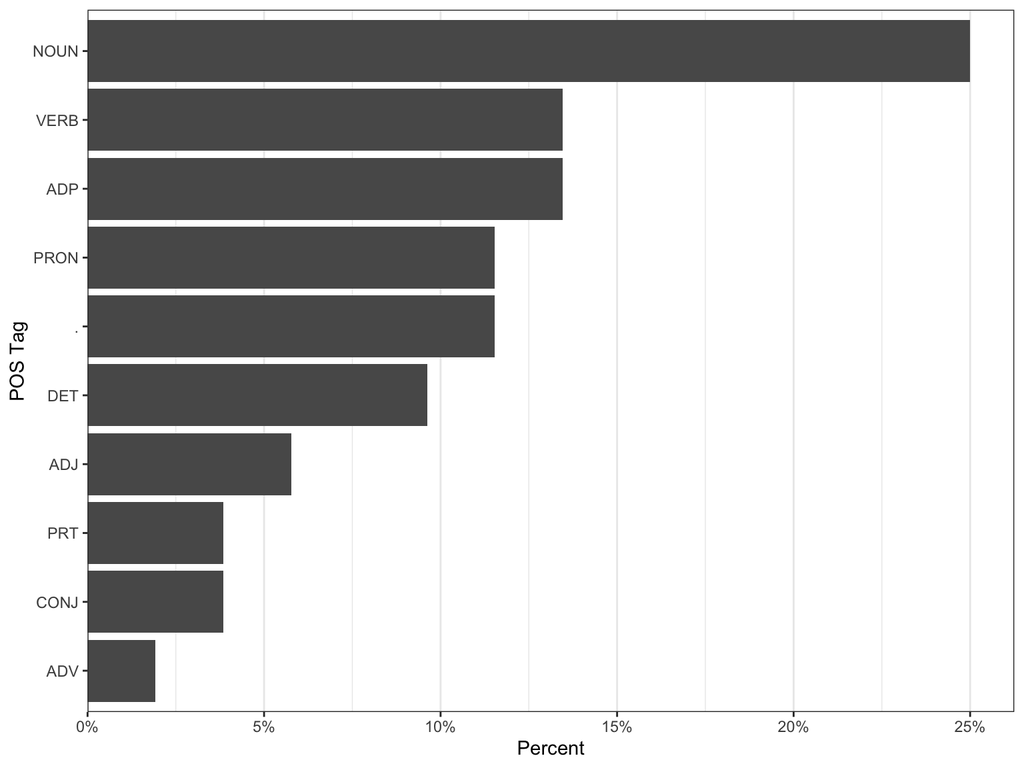

```r
##r chunk
tag_pos(sentence) %>% as_universal() %>% plot()
```

# qdap Package

- This package has a similar set of functions, which saves as a dataframe that you can print out the parts that you need

```r
##r chunk
library(qdap)
pos_saved <- pos(sentence)
pos_saved$POStagged
```

```
##                                                                                                                                                                                                                                                                                                          …
## 1 we/PRP cannot/DT nor/CC would/MD we/PRP fire/NN professor/NN person/NN for/IN his/PRP$ posts/NNS as/IN a/DT private/JJ citizen/NN as/IN vile/JJ and/CC stupid/JJ as/IN they/PRP are/VBP because/IN the/DT first/JJ amendment/NN of/IN the/DT united/VBN states/NNS constitution/NN forbids/VBZ us/PRP t…
##                                                                                                                                                                                                POStags
## 1 PRP, DT, CC, MD, PRP, NN, NN, NN, IN, PRP$, NNS, IN, DT, JJ, NN, IN, JJ, CC, JJ, IN, PRP, VBP, IN, DT, JJ, NN, IN, DT, VBN, NNS, NN, VBZ, PRP, TO, VB, RB, PRP, VBD, IN, DT, NN, VBD, TO, DT, NN, NN
##   word.count
## 1         46
```

```r
pos_saved$POSprop
```

```
##   wrd.cnt   propCC   propDT   propIN   propJJ   propMD   propNN  propNNS
## 1      46 4.347826 13.04348 15.21739 8.695652 2.173913 19.56522 4.347826
##    propPRP propPRP.   propRB   propTO   propVB  propVBD  propVBN  propVBP
## 1 10.86957 2.173913 2.173913 4.347826 2.173913 4.347826 2.173913 2.173913
##    propVBZ
## 1 2.173913
```

# qdap Package

- You can also view the tag set to understand the results

```r
##r chunk
pos_tags()
```

```
##    Tag  Description
## 1  CC   Coordinating conjunction
## 2  CD   Cardinal number
## 3  DT   Determiner
## 4  EX   Existential there
## 5  FW   Foreign word
## 6  IN   Preposition or subordinating conjunction
## 7  JJ   Adjective
## 8  JJR  Adjective, comparative
## 9  JJS  Adjective, superlative
## 10 LS   List item marker
## 11 MD   Modal
## 12 NN   Noun, singular or mass
## 13 NNS  Noun, plural
## 14 NNP  Proper noun, singular
```

[output cut: 22 more lines]

# RDR POS Tagger

- Ripple Down Rules-based Part-Of-Speech Tagger (RDRPOS)
- One of the largest set of languages supported
- Based on the corpora at https://universaldependencies.org/

# RDR POS Tagger

- Use `rdr_availabe_models()` to see what languages and options are available

```r
##r chunk
library(RDRPOSTagger)
models <- rdr_available_models()
models
```

```
## Riple down Rule based available taggers:
## ----------------------------------------
##
## 1/ POS tagging for languages:
## English, French, German, Hindi, Italian, Thai, Vietnamese
##
## 2/ MORPH tagging for languages:
## Bulgarian, Czech, Dutch, French, German, Portuguese, Spanish, Swedish
##
## 3/ UniversalPOS tagging for languages:
## Ancient_Greek-PROIEL, Ancient_Greek, Arabic, Basque, Belarusian, Bulgarian, Catalan, Chinese, Coptic, Croatian, Czech-CAC, Czech-CLTT, Czech, Danish, Dutch-LassySmall, Dutch, English-LinES, English-ParTUT, English, Estonian, Finnish-FTB, Finnish, French-ParTUT, French-Sequoia, French, Galician-Tr…
```

# RDR POS Tagger

- This package runs more “python-style”
- First you set the parameters of your tagger by noting language and annotation type
- Then you tell it to tag a sentence
- Output is a dataframe that includes the POS tag as a column

# RDR POS Tagger

```r
##r chunk
create_tagger <- rdr_model(language = "English", annotation = "POS")
rdr_pos(create_tagger, x = sentence)
```

```
##    doc_id token_id        token  pos
## 1      d1        1           We  PRP
## 2      d1        2       cannot   NN
## 3      d1        3            ,    ,
## 4      d1        4          nor   CC
## 5      d1        5        would   MD
## 6      d1        6           we  PRP
## 7      d1        7            ,    ,
## 8      d1        8         fire   NN
## 9      d1        9    Professor  NNP
## 10     d1       10       Person   NN
## 11     d1       11          for   IN
## 12     d1       12          his PRP$
## 13     d1       13        posts  NNS
## 14     d1       14           as   IN
```

[output cut: 38 more lines]

# udpipe Tagger + More!

```r
library(udpipe)
tagged <- udpipe(sentence, object = "english")
tagged[1:10, c("token", "lemma", "upos", "feats")]
```

```
##        token     lemma  upos                                      feats
## 1         We        we  PRON Case=Nom|Number=Plur|Person=1|PronType=Prs
## 2     cannot    cannot  VERB           Mood=Ind|Tense=Pres|VerbForm=Fin
## 3          ,         , PUNCT                                       <NA>
## 4        nor       nor CCONJ                                       <NA>
## 5      would     would   AUX                               VerbForm=Fin
## 6         we        we  PRON Case=Nom|Number=Plur|Person=1|PronType=Prs
## 7          ,         , PUNCT                                       <NA>
## 8       fire      fire  VERB           Mood=Ind|Tense=Pres|VerbForm=Fin
## 9  Professor Professor PROPN                                Number=Sing
## 10    Person    person PROPN                                Number=Sing
```

# On to Python

- `nltk` includes multiple POS tagging options
- `spaCy` would be “state of the art”
- Setup is a bit less strenuous than dealing with Java

# NLTK

- The basic `pos_tag` option has been trained to handle most tagging fairly effectively

```python
##python chunk
import nltk
tokens = nltk.word_tokenize(sentence)
nltk.pos_tag(tokens)
```

```
## [('We', 'PRP'), ('can', 'MD'), ('not', 'RB'), (',', ','), ('nor', 'CC'), ('would', 'MD'), ('we', 'PRP'), (',', ','), ('fire', 'NN'), ('Professor', 'NNP'), ('Person', 'NNP'), ('for', 'IN'), ('his', 'PRP$'), ('posts', 'NNS'), ('as', 'IN'), ('a', 'DT'), ('private', 'JJ'), ('citizen', 'NN'), (',', ',…
```

# A word about Tuples

- We’ve previously compared python lists with R vectors
  - In python, you can tell it’s a list by looking for the `[]` in the output
  - Just like in R, you can change items in a list, by using slicing
- Tuples are an ordered collection - can be any number of objects
  - Tuples are *immutable* meaning you cannot change them
  - You can tell it’s a tuple by looking for `()`
- Much of the output from these models is a list of tuples, which means we can loop through those objects to do other tasks with them

# spaCy

- Note: we already imported spacy and loaded the English language module
- Also note: we did this a slightly different way earlier, both are valid
- The `pandas` way is likely more useful

```python
##python chunk
tagged_sentence = nlp(sentence)
for word in tagged_sentence:
  print(word.text, word.pos_, word.tag_)
```

```
## We PRON PRP
## can VERB MD
## not PART RB
## , PUNCT ,
## nor CCONJ CC
## would VERB MD
## we PRON PRP
## , PUNCT ,
## fire NOUN NN
## Professor PROPN NNP
## Person PROPN NNP
## for ADP IN
## his DET PRP$
## posts NOUN NNS
## as SCONJ IN
## a DET DT
## private ADJ JJ
## citizen NOUN NN
## , PUNCT ,
## as SCONJ IN
## vile NOUN NN
## and CCONJ CC
## stupid ADJ JJ
## as SCONJ IN
## they PRON PRP
## are AUX VBP
## , PUNCT ,
## because SCONJ IN
## the DET DT
## First PROPN NNP
## Amendment PROPN NNP
## of ADP IN
## the DET DT
## United PROPN NNP
## States PROPN NNP
## Constitution PROPN NNP
## forbids VERB VBZ
## us PRON PRP
## to PART TO
## do AUX VB
## so ADV RB
## , PUNCT ,
## she PRON PRP
## wrote VERB VBD
## in ADP IN
## a DET DT
## letter NOUN NN
## posted VERB VBN
## to ADP IN
## the DET DT
## university NOUN NN
## website NOUN NN
## . PUNCT .
```

# Training your own tagger

- Let’s start with the classics using `nltk`
  - Default tagger
  - Regular expression tagger
  - Lookup tagger
  - Unigram or more taggers
  - Combination tagging

# The Default Tagger

- We can start by assigning everything to the most common option, usually NN for noun.
- Obviously, this won’t be very good, but it’s a place to start.
- Generally, after you process a lot of text, the “unseen” words will be nouns (as other words repeat a lot), so a default tagger can help get those right and easily.

```python
##python chunk
##we have already used import nltk
from nltk.corpus import brown

##create a function to give it the default of NN
default_tagger = nltk.DefaultTagger('NN')

##assign that to tokenized Brown words
tokens = brown.words(categories = "news") #just randomly picking the news words

#tag those words!
pd.DataFrame(default_tagger.tag(tokens)).head
```

```
## <bound method NDFrame.head of              0   1
## 0          The  NN
## 1       Fulton  NN
## 2       County  NN
## 3        Grand  NN
## 4         Jury  NN
## ...        ...  ..
## 100549       ,  NN
## 100550    read  NN
## 100551      ''  NN
## 100552       !  NN
## 100553       !  NN
##
## [100554 rows x 2 columns]>
```

# The Default Tagger

- Just how good is tagging everything as a noun?

```python
##python chunk
##a set with the answers
brown_tagged_sents = brown.tagged_sents()

##evaluate how well the tagger words against a known set
default_tagger.evaluate(brown_tagged_sents)
```

```
## 0.13130472824476916
```

# Regular Expression Tagger

```python
##python chunk
patterns = [
(r'.*ing$', 'VBG'),               # gerunds
(r'.*ed$', 'VBD'),                # simple past
(r'.*es$', 'VBZ'),                # 3rd singular present
(r'.*ould$', 'MD'),               # modals
(r'.*\'s$', 'NN$'),               # possessive nouns
(r'.*s$', 'NNS'),                 # plural nouns
(r'^-?[0-9]+(.[0-9]+)?$', 'CD'),  # cardinal numbers
(r'.*', 'NN')                     # nouns (default)
]
```

# Regular Expression Tagger

```python
##python chunk
##make a function for regex tagger
regexp_tagger = nltk.RegexpTagger(patterns)

##apply that function
##remember that tokens is untagged brown words
pd.DataFrame(regexp_tagger.tag(tokens))[40:50] #just printing out some words

##how good is that
```

```
##            0    1
## 40  over-all   NN
## 41    charge   NN
## 42        of   NN
## 43       the   NN
## 44  election   NN
## 45         ,   NN
## 46        ``   NN
## 47  deserves  VBZ
## 48       the   NN
## 49    praise   NN
```

```python
regexp_tagger.evaluate(brown_tagged_sents)
```

```
## 0.19537768086586887
```

# The Lookup Tagger

- A lot of high-frequency words do not have the NN tag.
- Let’s find the hundred most frequent words and store their most likely tag.
- We can then use this information as the model for a lookup tagger

```python
##python chunk
##create a frequency distribution of the target word set
fd = nltk.FreqDist(brown.words(categories='news'))
##pull out the top 100 words
most_freq_words = fd.most_common(100)

##create a conditional frequency distribution of the
##known word set, remember this is going to be word-pos
cfd = nltk.ConditionalFreqDist(brown.tagged_words(categories='news'))
pd.DataFrame(cfd)
```

```
##            The  Fulton  County  Grand  ...  vitally  16-22  richer  fuller
## AT       775.0     NaN     NaN    NaN  ...      NaN    NaN     NaN     NaN
## AT-TL     28.0     NaN     NaN    NaN  ...      NaN    NaN     NaN     NaN
## AT-HL      3.0     NaN     NaN    NaN  ...      NaN    NaN     NaN     NaN
## NP-TL      NaN    10.0     NaN    NaN  ...      NaN    NaN     NaN     NaN
## NP         NaN     4.0     NaN    NaN  ...      NaN    NaN     NaN     NaN
## ...        ...     ...     ...    ...  ...      ...    ...     ...     ...
## FW-AT      NaN     NaN     NaN    NaN  ...      NaN    NaN     NaN     NaN
## FW-*       NaN     NaN     NaN    NaN  ...      NaN    NaN     NaN     NaN
## FW-CD      NaN     NaN     NaN    NaN  ...      NaN    NaN     NaN     NaN
## FW-WDT     NaN     NaN     NaN    NaN  ...      NaN    NaN     NaN     NaN
## WDT+BEZ    NaN     NaN     NaN    NaN  ...      NaN    NaN     NaN     NaN
##
## [218 rows x 14394 columns]
```

# The Lookup Tagger

```python
##python chunk
##create a dictionary of the words
##pull the max word-pos combination from our known set
##but only for words in our target word set
likely_tags = dict((word, cfd[word].max()) for (word, _) in most_freq_words)

##create the baseline_tagger function
##using model of our likely words
##and backoff which is adding the default guess of NN rather than none
baseline_tagger = nltk.UnigramTagger(model=likely_tags,
                                     backoff=nltk.DefaultTagger('NN'))
##examine how well it tags versus the known words
baseline_tagger.evaluate(brown_tagged_sents)
```

```
## 0.5980888604124038
```

# Unigram Tagger

- The previous slide showed an example of how the unigram tagger works
- For each word, pick the most common POS for that word.
- For example, the word frequent would be assigned to adjective, even though it can be a noun.
- Works much like a lookup tagger, but this system allows us to do tag training.
- Training occurs where we look at each POS and store the most likely tag for each word in a dictionary.

# Unigram Tagger

```python
##python chunk
##create a unigram tagger function
unigram_tagger = nltk.UnigramTagger(brown_tagged_sents)
##lets see what it does
unigram_tagger.tag(tokens)[:50]

##what's the performance?
```

```
## [('The', 'AT'), ('Fulton', 'NP-TL'), ('County', 'NN-TL'), ('Grand', 'JJ-TL'), ('Jury', 'NN-TL'), ('said', 'VBD'), ('Friday', 'NR'), ('an', 'AT'), ('investigation', 'NN'), ('of', 'IN'), ("Atlanta's", 'NP$'), ('recent', 'JJ'), ('primary', 'JJ'), ('election', 'NN'), ('produced', 'VBN'), ('``', '``')…
```

```python
unigram_tagger.evaluate(brown_tagged_sents)
```

```
## 0.9245482228606466
```

# Unigram Tagger

- This tagger is the first we’ve used that “trains” - the rest were simple “here’s the rules go!” taggers
- We should not train and test on the same data (that’s cheating!)
- Often people do a 90-10 or 80-20 split of the data to test and then train

# Unigram Tagger

```python
##python chunk
##figure out where the split is
size = int(len(brown_tagged_sents) * 0.9)
##break apart the data based on that split
train_sents = brown_tagged_sents[:size]
test_sents = brown_tagged_sents[size:]

##create a function (training) on the first part
unigram_tagger = nltk.UnigramTagger(train_sents)
##test on the second part
unigram_tagger.evaluate(test_sents)
```

```
## 0.8849353534083527
```

# Combining Taggers

- One way to address the trade-off between accuracy and coverage is to use the more accurate algorithms when we can, but to fall back on algorithms with wider coverage when necessary.
- For example, we could combine the results of a bigram tagger, a unigram tagger, and a default tagger

```python
##python chunk
##default to noun
t0 = nltk.DefaultTagger('NN')
##single words in context, go back to noun if necessary
t1 = nltk.UnigramTagger(train_sents, backoff=t0)
##double words in context, back up to single words
t2 = nltk.BigramTagger(train_sents, backoff=t1)
##how accurate is that
t2.evaluate(test_sents)
```

```
## 0.9125751765470128
```

# Spacy Training

- Spacy provides language models that have already been trained for part of speech tagging.
- You can train your own though, which would be especially useful for specialized datasets (chats, etc.).
- Generally this type of training is an underlying neural net model
- You can learn more about it here: https://spacy.io/usage/training#tagger-parser

# Summary

- In this section, we covered part of speech tagging by first thinking about the structure of language as our guide
- We covered how you tag words in *R* and Python, followed by building your own classifiers/taggers in Python with NLTK (simple) and expanding with Spacy (more complex but powerful)
- We can use these skills to start to do more interesting questions, like entity recognition and dependency parsing